# Interpreting Models with RuleFit

Bruce Hartman

University of St. Francis

2026-10-06 Revised 2026-10-11T12:51:33

Abstract

We present the RuleFit surrogate model method for interpretability, using the `pre` package.

# Introduction

RuleFit is an interpretation method that builds a rule-based interpretation of an AI black-box model. It’s implemented in the `pre` package. It works by building a rule-based decision tree. The rules can be used to ‘explain’ the black-box model. See Molnar, 2025.

It’s a form of surrogate model, made by adding variables for rules to the original regression.

RuleFit (and `pre`) is essentially a linear model. It generates rules as 0-1 dummy variables based on a decision tree output. Then it adds these dummy variables to the model and runs a lasso regression to weed out the unimportant ones. Remember that lasso regression eliminates variables that don’t contribute much to the objective.

The lasso regression is repeated on each decision tree found, using crossvalidation. We end up with a selection of rules and coefficients for them produced by the lasso regressions. Importances for the rule, since they are just variables now, can also be calculated. For linear regression importances are related to the t-values of the coefficients.

We wind up with coefficients of each rule, that show how much the rule contributes to changing the target variable, and in what direction. We also get importances of the rules (variables), which allow us to rank the rules according to importance. The top ranked rules in importance form an ‘explanation’ of the black-box model.

# Packages

```r
library(randomForest)
library(ISLR2)
library(mbadtools)
```

# 1. Data

The Boston dataset is in the `ISLR2` package.

```r
data(Boston)
```

# Research Question

Can we explain or interpret a complex random forest model using the RuleFit method?

# Design

Split data for training and test.

```r
# Split data into training and testing sets
set.seed(42) # for reproducibility
trainSplit <- initial_split(Boston, prop = 0.8, strata = medv)
boston_train <- training(trainSplit)
boston_test <- testing(trainSplit)
```

# 2. Train random forest model

The `randomForest` package provides a simple interface. We will use all other variables to predict `medv`.

```r
rf_model <- randomForest(medv ~ .,
                         data = boston_train,
                         ntree = 500, importance = TRUE)
```

Print a summary of the random forest model

```r
print(rf_model)
```

```
Call:
 randomForest(formula = medv ~ ., data = boston_train, ntree = 500,      importance = TRUE)
               Type of random forest: regression
                     Number of trees: 500
No. of variables tried at each split: 4

          Mean of squared residuals: 10.61759
                    % Var explained: 87.93
```

# Variable Importance

`randomforest` computes variable importances internally. View variable importance; we can compute a nice chart using “model” importances with `vip` and a plot routine.

```r
randomForest::importance(rf_model)
```

```
          %IncMSE IncNodePurity
crim    16.772589     2166.7893
zn       5.126298      459.1327
indus   12.058840     2334.2838
chas     3.824802      163.5195
nox     14.965321     2530.3643
rm      32.694713     9686.8389
age     13.166858      860.9206
dis     17.835140     2133.3280
rad      6.391415      319.8559
tax     13.013256     1114.4476
ptratio 14.866588     2003.7427
black    8.839135      615.7065
lstat   29.842553    10235.7558
```

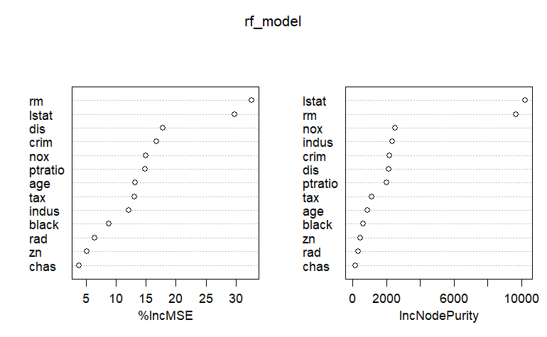

```r
varImpPlot(rf_model)
```

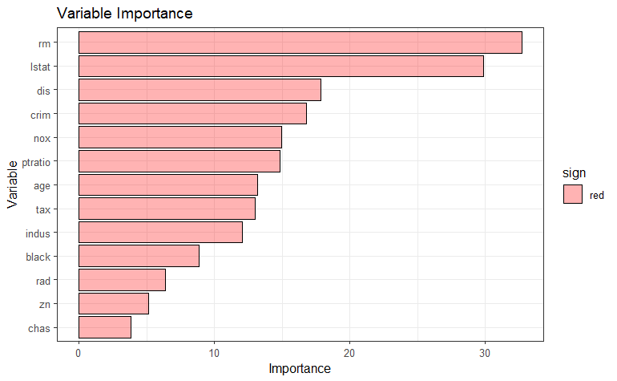

```r
rf_model %>% vi() %>% gg_vip()
```

# Interpret using `pre`

The `pre` package creates a prediction rule ensemble (PRE), which provides interpretable rules. Use the `pre()` function on the same training data to find predictive rules.

The algorithm is largely based on the RuleFit method. See Molnar, 2025

```r
pre_model <- pre(medv ~ ., data = boston_train,
                 family = "gaussian", ntrees = 100)
```

Print a summary of the prediction rule ensemble model. In tree construction randomness is used.

```r
print(pre_model) %>% gt()
```

```
Final ensemble with cv error within 1se of minimum:

  lambda =  0.1253707
  number of terms = 58
  mean cv error (se) = 15.80144 (5.376271)

  cv error type : Mean-Squared Error

         rule   coefficient
  (Intercept)  28.904871109
       rule31   3.101038683
      rule397   2.496369321
      rule189   2.400711510
      rule571  -1.463215441
        rule5   1.352070648
      rule839  -1.316944589
      rule726   1.233332616
      rule491   1.230898788
      rule515   1.208540526
      rule335   1.172849296
      rule250  -1.052311026
      rule768  -1.048534968
      rule613  -1.045623067
      rule169  -1.035621977
      rule790   0.938363927
      rule674  -0.904447318
      rule271   0.898229140
      rule784  -0.851526292
      rule355   0.821946198
      rule708   0.817984221
      rule865  -0.796732606
         chas   0.762359461
      rule599  -0.720031345
      rule815  -0.704202560
      rule400  -0.703019552
      rule252   0.699731844
           rm   0.662121397
       rule50   0.588565672
      rule380   0.526547334
      rule230  -0.493464042
```

[output cut: 73 more lines]

```
    lstat > 5.33 & lstat > 9.67 & crim > 0.7857
      lstat <= 8.1 & rm <= 7.007 & lstat > 5.33
                                  lstat <= 9.69
                    lstat > 5.33 & lstat > 9.67
                                    rm <= 6.538
                      lstat <= 8.1 & rm > 6.874
                       3.11 <= lstat <= 29.9555
                  lstat > 9.93 & crim > 14.0507
     lstat <= 8.1 & rm <= 6.874 & lstat > 4.38
                    lstat <= 9.62 & rm > 6.871
 lstat > 8.1 & lstat <= 19.52 & black > 227.61
                     1.34644 <= dis <= 8.90097
  rm <= 6.976 & lstat > 14.66 & crim > 7.40389
                      22.142 <= black <= 396.9
      lstat > 9.93 & lstat > 14.81 & tax > 437
```

| rule | coefficient | description |
| --- | --- | --- |
| (Intercept) | 28.904871109 | 1 |
| rule31 | 3.101038683 | lstat <= 8.1 & rm > 6.874 & rm > 7.42 |
| rule397 | 2.496369321 | lstat <= 9.62 & crim > 1.42502 |
| rule189 | 2.400711510 | lstat <= 9.93 & rm > 6.635 |
| rule571 | -1.463215441 | rm <= 7.007 |
| rule5 | 1.352070648 | lstat <= 9.93 & rm > 6.939 |
| rule839 | -1.316944589 | lstat > 9.93 & tax > 279 |
| rule726 | 1.233332616 | rm <= 6.824 & lstat <= 14.37 & rad > 8 |
| rule491 | 1.230898788 | lstat <= 8.1 & rm > 7.007 |
| rule515 | 1.208540526 | rm > 6.794 & rm > 7.47 |
| rule335 | 1.172849296 | lstat <= 9.93 & crim > 0.52058 |
| rule250 | -1.052311026 | lstat > 7.56 & lstat > 14.36 & tax > 437 |
| rule768 | -1.048534968 | lstat > 9.53 & lstat > 19.52 & nox > 0.671 |
| rule613 | -1.045623067 | lstat > 9.69 & crim > 7.40389 |
| rule169 | -1.035621977 | lstat <= 9.93 & rm <= 7.416 & crim <= 1.42502 |
| rule790 | 0.938363927 | lstat <= 9.93 & crim > 0.49298 |
| rule674 | -0.904447318 | lstat > 5.04 & tax > 296 |
| rule271 | 0.898229140 | lstat <= 5.33 |
| rule784 | -0.851526292 | rm <= 6.782 & lstat > 14.37 & age > 72.9 |
| rule355 | 0.821946198 | lstat <= 5.12 |
| rule708 | 0.817984221 | lstat <= 5.91 & dis <= 5.885 |
| rule865 | -0.796732606 | lstat > 7.26 & crim <= 6.80117 & rm <= 6.14 |
| chas | 0.762359461 | 0 <= chas <= 1 |
| rule599 | -0.720031345 | lstat > 5.1 & lstat > 12.13 & crim > 0.17899 |
| rule815 | -0.704202560 | rm <= 7.42 & lstat <= 12.13 & crim <= 3.67367 |
| rule400 | -0.703019552 | lstat > 9.62 & lstat > 17.6 & dis <= 2.0026 |
| rule252 | 0.699731844 | lstat <= 5.91 & dis <= 3.3751 |
| rm | 0.662121397 | 5.0006 <= rm <= 7.8519 |
| rule50 | 0.588565672 | lstat <= 7.39 & lstat <= 4.63 |
| rule380 | 0.526547334 | rm > 6.649 & lstat <= 7.56 |
| rule230 | -0.493464042 | lstat > 9.59 & lstat > 14.81 & crim > 4.42228 |
| rule170 | 0.454721382 | lstat <= 9.93 & rm <= 7.416 & crim > 1.42502 |
| rule108 | -0.431566063 | lstat > 7.79 & lstat > 16.03 & dis <= 2.4298 |
| rule885 | -0.400020112 | rm <= 7.412 & lstat > 9.67 & crim > 12.0482 |
| rule737 | -0.399013454 | lstat > 5.33 & tax <= 437 & rm <= 6.481 |
| rule527 | -0.394963086 | rm <= 6.976 & lstat > 14.36 & crim > 0.54452 |
| rule758 | 0.360848063 | lstat <= 9.53 |
| rule329 | 0.360518497 | lstat <= 5.33 & age > 29.1 |
| rule24 | -0.349634006 | lstat > 7.56 & lstat > 14.81 & crim > 0.75026 |
| ptratio | -0.322602389 | 13 <= ptratio <= 21.2 |
| rule76 | 0.319286354 | lstat <= 9.62 |
| rule164 | -0.282573329 | rm <= 6.976 & lstat > 9.64 |
| rule14 | 0.269058648 | lstat <= 7.56 |
| rule667 | -0.267866873 | lstat > 7.56 & lstat > 14.37 & tax > 391 |
| rule686 | -0.232685762 | lstat > 5.33 & lstat > 9.67 & crim > 0.7857 |
| rule490 | -0.224615444 | lstat <= 8.1 & rm <= 7.007 & lstat > 5.33 |
| rule291 | 0.209230287 | lstat <= 9.69 |
| rule684 | -0.170585444 | lstat > 5.33 & lstat > 9.67 |
| rule459 | -0.160711905 | rm <= 6.538 |
| rule29 | 0.154652893 | lstat <= 8.1 & rm > 6.874 |
| lstat | -0.151803845 | 3.11 <= lstat <= 29.9555 |
| rule794 | -0.072574350 | lstat > 9.93 & crim > 14.0507 |
| rule28 | -0.072464519 | lstat <= 8.1 & rm <= 6.874 & lstat > 4.38 |
| rule80 | 0.066046710 | lstat <= 9.62 & rm > 6.871 |
| rule494 | 0.035464181 | lstat > 8.1 & lstat <= 19.52 & black > 227.61 |
| dis | -0.025860525 | 1.34644 <= dis <= 8.90097 |
| rule429 | -0.016237863 | rm <= 6.976 & lstat > 14.66 & crim > 7.40389 |
| black | 0.001951869 | 22.142 <= black <= 396.9 |
| rule13 | -0.001196796 | lstat > 9.93 & lstat > 14.81 & tax > 437 |

Get the most important rules.

```r
coefs = coef(pre_model)
coefs %>%
  filter(rule !="(Intercept)" & abs(coefficient)>0) %>%
  gt()
```

| rule | coefficient | description |
| --- | --- | --- |
| rule31 | 3.101038683 | lstat <= 8.1 & rm > 6.874 & rm > 7.42 |
| rule397 | 2.496369321 | lstat <= 9.62 & crim > 1.42502 |
| rule189 | 2.400711510 | lstat <= 9.93 & rm > 6.635 |
| rule571 | -1.463215441 | rm <= 7.007 |
| rule5 | 1.352070648 | lstat <= 9.93 & rm > 6.939 |
| rule839 | -1.316944589 | lstat > 9.93 & tax > 279 |
| rule726 | 1.233332616 | rm <= 6.824 & lstat <= 14.37 & rad > 8 |
| rule491 | 1.230898788 | lstat <= 8.1 & rm > 7.007 |
| rule515 | 1.208540526 | rm > 6.794 & rm > 7.47 |
| rule335 | 1.172849296 | lstat <= 9.93 & crim > 0.52058 |
| rule250 | -1.052311026 | lstat > 7.56 & lstat > 14.36 & tax > 437 |
| rule768 | -1.048534968 | lstat > 9.53 & lstat > 19.52 & nox > 0.671 |
| rule613 | -1.045623067 | lstat > 9.69 & crim > 7.40389 |
| rule169 | -1.035621977 | lstat <= 9.93 & rm <= 7.416 & crim <= 1.42502 |
| rule790 | 0.938363927 | lstat <= 9.93 & crim > 0.49298 |
| rule674 | -0.904447318 | lstat > 5.04 & tax > 296 |
| rule271 | 0.898229140 | lstat <= 5.33 |
| rule784 | -0.851526292 | rm <= 6.782 & lstat > 14.37 & age > 72.9 |
| rule355 | 0.821946198 | lstat <= 5.12 |
| rule708 | 0.817984221 | lstat <= 5.91 & dis <= 5.885 |
| rule865 | -0.796732606 | lstat > 7.26 & crim <= 6.80117 & rm <= 6.14 |
| chas | 0.762359461 | 0 <= chas <= 1 |
| rule599 | -0.720031345 | lstat > 5.1 & lstat > 12.13 & crim > 0.17899 |
| rule815 | -0.704202560 | rm <= 7.42 & lstat <= 12.13 & crim <= 3.67367 |
| rule400 | -0.703019552 | lstat > 9.62 & lstat > 17.6 & dis <= 2.0026 |
| rule252 | 0.699731844 | lstat <= 5.91 & dis <= 3.3751 |
| rm | 0.662121397 | 5.0006 <= rm <= 7.8519 |
| rule50 | 0.588565672 | lstat <= 7.39 & lstat <= 4.63 |
| rule380 | 0.526547334 | rm > 6.649 & lstat <= 7.56 |
| rule230 | -0.493464042 | lstat > 9.59 & lstat > 14.81 & crim > 4.42228 |
| rule170 | 0.454721382 | lstat <= 9.93 & rm <= 7.416 & crim > 1.42502 |
| rule108 | -0.431566063 | lstat > 7.79 & lstat > 16.03 & dis <= 2.4298 |
| rule885 | -0.400020112 | rm <= 7.412 & lstat > 9.67 & crim > 12.0482 |
| rule737 | -0.399013454 | lstat > 5.33 & tax <= 437 & rm <= 6.481 |
| rule527 | -0.394963086 | rm <= 6.976 & lstat > 14.36 & crim > 0.54452 |
| rule758 | 0.360848063 | lstat <= 9.53 |
| rule329 | 0.360518497 | lstat <= 5.33 & age > 29.1 |
| rule24 | -0.349634006 | lstat > 7.56 & lstat > 14.81 & crim > 0.75026 |
| ptratio | -0.322602389 | 13 <= ptratio <= 21.2 |
| rule76 | 0.319286354 | lstat <= 9.62 |
| rule164 | -0.282573329 | rm <= 6.976 & lstat > 9.64 |
| rule14 | 0.269058648 | lstat <= 7.56 |
| rule667 | -0.267866873 | lstat > 7.56 & lstat > 14.37 & tax > 391 |
| rule686 | -0.232685762 | lstat > 5.33 & lstat > 9.67 & crim > 0.7857 |
| rule490 | -0.224615444 | lstat <= 8.1 & rm <= 7.007 & lstat > 5.33 |
| rule291 | 0.209230287 | lstat <= 9.69 |
| rule684 | -0.170585444 | lstat > 5.33 & lstat > 9.67 |
| rule459 | -0.160711905 | rm <= 6.538 |
| rule29 | 0.154652893 | lstat <= 8.1 & rm > 6.874 |
| lstat | -0.151803845 | 3.11 <= lstat <= 29.9555 |
| rule794 | -0.072574350 | lstat > 9.93 & crim > 14.0507 |
| rule28 | -0.072464519 | lstat <= 8.1 & rm <= 6.874 & lstat > 4.38 |
| rule80 | 0.066046710 | lstat <= 9.62 & rm > 6.871 |
| rule494 | 0.035464181 | lstat > 8.1 & lstat <= 19.52 & black > 227.61 |
| dis | -0.025860525 | 1.34644 <= dis <= 8.90097 |
| rule429 | -0.016237863 | rm <= 6.976 & lstat > 14.66 & crim > 7.40389 |
| black | 0.001951869 | 22.142 <= black <= 396.9 |
| rule13 | -0.001196796 | lstat > 9.93 & lstat > 14.81 & tax > 437 |

The `pre` package allows you to extract and inspect the most influential rules. We choose the first 6 in importance. the plot displays the rules as decision trees.

```r
pre::importance(pre_model, plot=F)$baseimps %>% head(6)
```

[output not shown]

We can plot the individual decision trees we found.

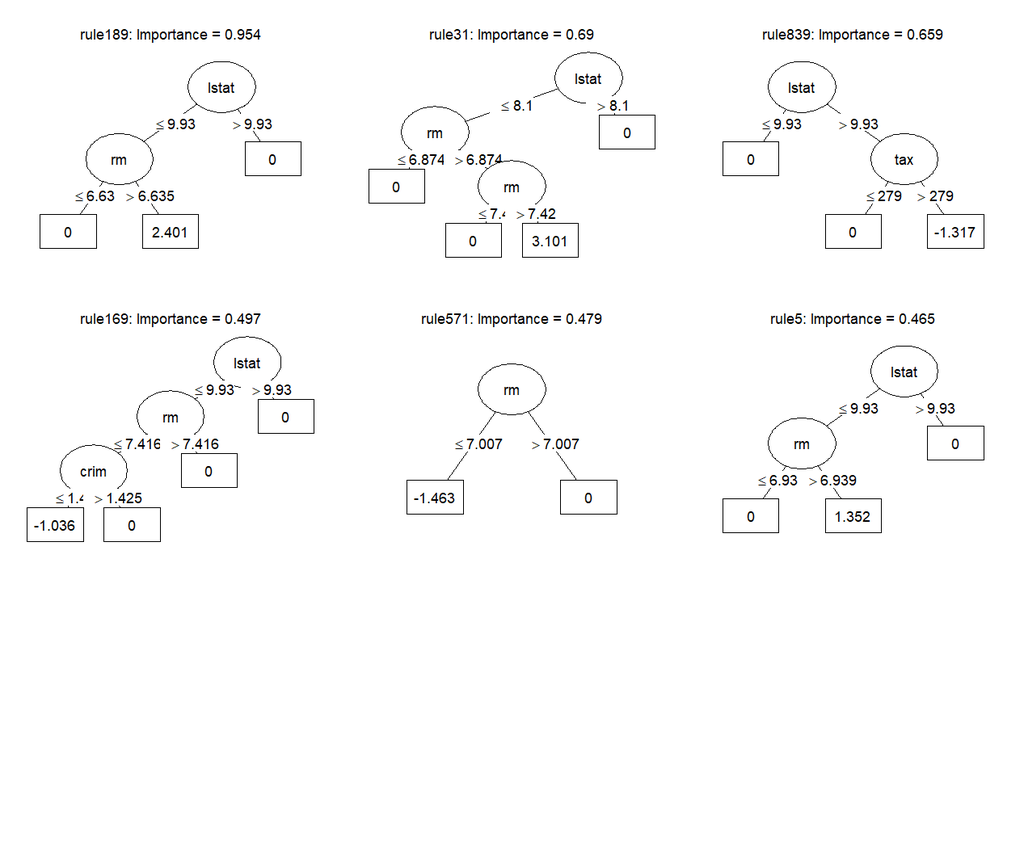

```r
plot(pre_model, linear.terms = FALSE, nterms=6)
```

The `print(pre_model)` output will also show the important rules and their coefficients.

```r
print(pre_model)[1:7,]
```

```
Final ensemble with cv error within 1se of minimum:

  lambda =  0.1253707
  number of terms = 58
  mean cv error (se) = 15.80144 (5.376271)

  cv error type : Mean-Squared Error

         rule   coefficient
  (Intercept)  28.904871109
       rule31   3.101038683
      rule397   2.496369321
      rule189   2.400711510
      rule571  -1.463215441
        rule5   1.352070648
      rule839  -1.316944589
      rule726   1.233332616
      rule491   1.230898788
      rule515   1.208540526
      rule335   1.172849296
      rule250  -1.052311026
      rule768  -1.048534968
      rule613  -1.045623067
      rule169  -1.035621977
      rule790   0.938363927
      rule674  -0.904447318
      rule271   0.898229140
      rule784  -0.851526292
      rule355   0.821946198
      rule708   0.817984221
      rule865  -0.796732606
         chas   0.762359461
      rule599  -0.720031345
      rule815  -0.704202560
      rule400  -0.703019552
      rule252   0.699731844
           rm   0.662121397
       rule50   0.588565672
      rule380   0.526547334
      rule230  -0.493464042
```

[output cut: 73 more lines]

```
    lstat > 5.33 & lstat > 9.67 & crim > 0.7857
      lstat <= 8.1 & rm <= 7.007 & lstat > 5.33
                                  lstat <= 9.69
                    lstat > 5.33 & lstat > 9.67
                                    rm <= 6.538
                      lstat <= 8.1 & rm > 6.874
                       3.11 <= lstat <= 29.9555
                  lstat > 9.93 & crim > 14.0507
      lstat <= 8.1 & rm <= 6.874 & lstat > 4.38
                     lstat <= 9.62 & rm > 6.871
  lstat > 8.1 & lstat <= 19.52 & black > 227.61
                      1.34644 <= dis <= 8.90097
   rm <= 6.976 & lstat > 14.66 & crim > 7.40389
                       22.142 <= black <= 396.9
       lstat > 9.93 & lstat > 14.81 & tax > 437
```

[output not shown]

Retrieve the importances and make a `vip` graph.

```r
pre::importance(pre_model, plot=F)$baseimps
```

[output not shown]

[output cut: 48 more lines]

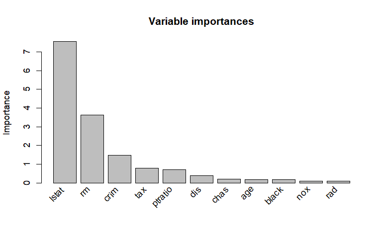

```r
pre::importance(pre_model) #graph
```

# 4. Compare model performance

Use the trained models to make predictions on the test set.

```r
rf_predictions <- predict(rf_model, newdata = boston_test)
pre_predictions <- predict(pre_model, newdata = boston_test)
```

# Compare Models

A good interpretation method or surrogate model should not sacrifice too much predictive accuracy. We choose RMSE and R-squared. We evaluate on the test dataset predictions.

```r
rf_rmse <- yardstick::rmse_vec(boston_test$medv, rf_predictions)
pre_rmse <- yardstick::rmse_vec(boston_test$medv, pre_predictions)

cat("Random Forest RMSE:", rf_rmse, "\n")
```

```
Random Forest RMSE: 2.825804
```

```r
cat("Rule-based (pre) RMSE:", pre_rmse, "\n")
```

```
Rule-based (pre) RMSE: 4.024562
```

```r
rf_rsq <- yardstick::rsq_vec(boston_test$medv, rf_predictions)
pre_rsq <- yardstick::rsq_vec(boston_test$medv, pre_predictions)

cat("\nRandom Forest R-squared:", rf_rsq, "\n")
```

```
Random Forest R-squared: 0.8901814
```

```r
cat("Rule-based (pre) R-squared:", pre_rsq, "\n")
```

```
Rule-based (pre) R-squared: 0.8013958
```

# 5. Extract/interpret rules

```r
pre::importance(pre_model, plot=F)$baseimps %>% head(6)
```

[output not shown]

Extract the rules with the largest coefficients, leaving out the Intercept rule:

```r
print(pre_model) %>% slice(2:7)
```

```
Final ensemble with cv error within 1se of minimum:

  lambda =  0.1253707
  number of terms = 58
  mean cv error (se) = 15.80144 (5.376271)

  cv error type : Mean-Squared Error

         rule   coefficient
  (Intercept)  28.904871109
       rule31   3.101038683
      rule397   2.496369321
      rule189   2.400711510
      rule571  -1.463215441
        rule5   1.352070648
      rule839  -1.316944589
      rule726   1.233332616
      rule491   1.230898788
      rule515   1.208540526
      rule335   1.172849296
      rule250  -1.052311026
      rule768  -1.048534968
      rule613  -1.045623067
      rule169  -1.035621977
      rule790   0.938363927
      rule674  -0.904447318
      rule271   0.898229140
      rule784  -0.851526292
      rule355   0.821946198
      rule708   0.817984221
      rule865  -0.796732606
         chas   0.762359461
      rule599  -0.720031345
      rule815  -0.704202560
      rule400  -0.703019552
      rule252   0.699731844
           rm   0.662121397
       rule50   0.588565672
      rule380   0.526547334
      rule230  -0.493464042
```

[output cut: 73 more lines]

```
    lstat > 5.33 & lstat > 9.67 & crim > 0.7857
      lstat <= 8.1 & rm <= 7.007 & lstat > 5.33
                                  lstat <= 9.69
                    lstat > 5.33 & lstat > 9.67
                                    rm <= 6.538
                      lstat <= 8.1 & rm > 6.874
                       3.11 <= lstat <= 29.9555
                  lstat > 9.93 & crim > 14.0507
      lstat <= 8.1 & rm <= 6.874 & lstat > 4.38
                     lstat <= 9.62 & rm > 6.871
  lstat > 8.1 & lstat <= 19.52 & black > 227.61
                      1.34644 <= dis <= 8.90097
   rm <= 6.976 & lstat > 14.66 & crim > 7.40389
                       22.142 <= black <= 396.9
       lstat > 9.93 & lstat > 14.81 & tax > 437
```

[output not shown]

# Partial Dependence

The `pre` package has a `singleplot` function to do this, but I prefer my own ggplot, from `gg_interpret.R`. We prepare the data with `pdp::partial`, adding the type=“regression” to avoid warnings.

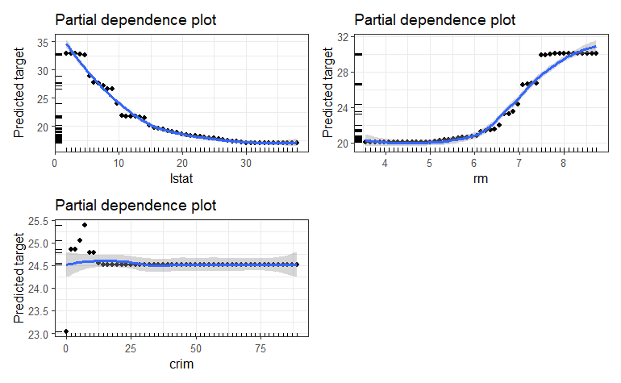

```r
wrap_plots(ncol=2, nrow=2,
  partial(pre_model, pred.var="lstat", train=boston_train,
             type="regression") %>%
    gg_pdp(),
  partial(pre_model, pred.var="rm", train=boston_train,
             type="regression") %>%
   gg_pdp(),
  partial(pre_model, pred.var="crim", train=boston_train,
             type="regression") %>%
    gg_pdp(),
ggally_blank()
)
```

# Predictions

Example predictions for the first 3 test communities.

```r
pre_predictions = predict(pre_model, newdata=boston_test[1:3,])
pre_predictions
```

```
       1        2        3
29.01704 16.71781 19.07241
```

# References

Gemini (2025) Model the Boston dataset with random forest and RuleFit using `pre`. Retrieved 10/17/2025 from (https://www.google.com/search?q=Build+a+script+in+R+to+model+the+Boston+dataset+with+a+random+forest+and+a+rule+fit+interpretation+with+the+pre+package&rlz=1C1RXQR_enUS1025US1025&sourceid=chrome&ie=UTF-8&udm=50&aep=48&cud=0&qsubts=1760714759685&mtid=P2DyaIK9HNHAkPIP06afcQ&mstk=AUtExfCVCB1LiAvbRigZDf9Emx1ZELilePM6MKAheVQFdr_4ex5X5B-YwMqVu6qzSbH3ur8tRFFdPsyHo4XCP8JUPEqpkpHwktpNB0oHJ_Hwust5ndEKMWCWwXyzqsqMEzIQpyxvvIUW7BtkF7BenLNsiAUCCLboW2GRZGO9wlzp2muW0HJF7HL4uJQQoe9zWKKodcIzxQNytHrzinBDSmOK-oMQdbjeP2ldGX4lwMLR2PWmh_S-6QGk64Xm5gq8DBSazXHccMj9nw5c3DfqjlpXQaFi5i3tFJqZuhM&csuir=1)

Hartman, Bruce (2025) Modeling Workflow Techniques. (https://chatgpt.com/c/68e41538-5894-8332-aeea-7ab0a0fd7b08)

Molnar, C. (2025) RuleFit. Chapter 11, Interpretable Machine Learning, 3rd edition, continuously updated. Retrieved online on 10/17/2025 from (https://christophm.github.io/interpretable-ml-book/rulefit.html)

Fokkema, M. (2020). Fitting prediction rule ensembles with r package pre. Journal of Statistical Software, 92(12), 1–30. https://doi.org/10.18637/jss.v092.i12

[R. Barton. (2025)](https://doi.org/10.1093/imaman/dpaf036) Response grid plots for model-agnostic machine learning insight. IMA Journal of Management Mathematics (2025) 36, 623–648. DOI: https://doi.org/10.1093/imaman/dpaf036 The [code is on GitHub](https://github.com/rrbarton51/ResponseGridPlots)